# Estadística Aplicada 3 - Proyecto final

Autores/as

Marcelino 191654

Daniela

Fecha de publicación

10 de diciembre de 2023

# Escalamiento multidimensional

**Código**

```r
#Cargamos paquetes
library(tidymodels)
library(discrim)
library(corrr)
library(paletteer)
library(MASS)
library(dslabs)
library(tidyr)
```

En Análisis de Componentes Principales (PCA), partimos de datos $x_i$ en un espacio $p$-dimensional y buscamos proyectarlos en un espacio de menor dimensión ($r < p$) representado por $y_1, \ldots, y_n$. Queremos que esta proyección minimice el error de reconstrucción o maximice la varianza.

El Enfoque Multidimensional (MDS), por otro lado, comienza con una matriz de distancias $D$, que contiene las distancias o disimilitudes entre los puntos de datos. Si consideramos $n$ unidades experimentales, $D$ sería una matriz $n \times n$. Es importante mencionar que esta matriz es simétrica, lo que significa que $d_{ij} = d_{ji}$, y también tiene valores de cero en la diagonal ($d_{ii} = 0$).

El objetivo es encontrar un conjunto de puntos en un espacio de dimensión reducida ($\mathbb{R}^r$), donde las distancias entre estos puntos sean lo más cercanas posible a las $d_{ij}$ en la matriz $D$.

En resumen, MDS busca representar estos datos en un espacio de menor dimensión de manera que las distancias entre los puntos reflejen fielmente las distancias originales entre los datos. A través de esta representación espacial, podemos comprender la estructura y relaciones subyacentes en los datos basados en las distancias entre ellos. El objetivo principal es encontrar $y_1, \ldots, y_k \in \mathbb{R}^r$ que minimicen la discrepancia entre las distancias originales y las distancias entre los puntos proyectados. Esto se puede expresar como el problema de optimización:

$$\sum_{i=1}^n \sum_{j=1}^n (d_{ij} - d(y_i, y_j))^2$$

donde $d(y_i, y_j)$ es la distancia entre los puntos $y_i$ y $y_j$ en el espacio de dimensión $r$.

Como resultado podemos obtener una representación visual que nos facilitaría la interpretación de las relaciones entre los datos y permite una clasificación más intuitiva basada en la proximidad visual.

## Ejemplo

Consideremos el conjunto de datos MNIST de dígitos escritos a mano. Esta es una colección de 60,000 dígitos, cada uno de los cuales ha sido convertido a una imagen de escala de grises de $28 \times 28$ píxeles (entonces $p = 784$).

Echemos un vistazo solo a los dígitos 7.

**Código**

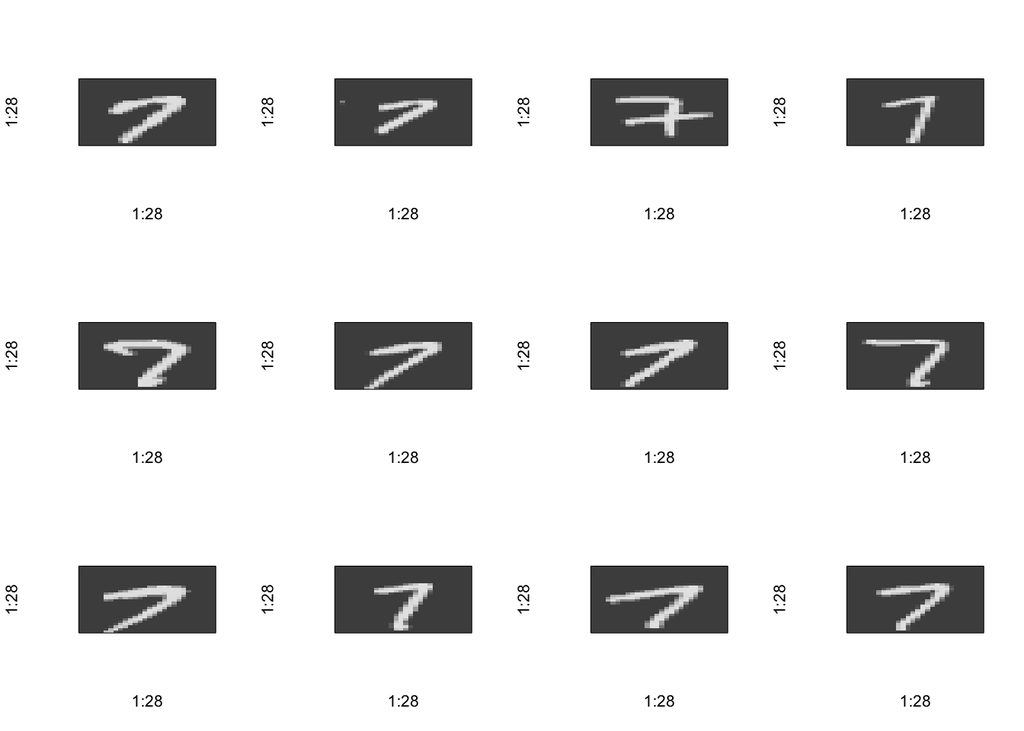

```r
mnist <- readRDS("mnist.rds")
mnist7 = mnist$train$x[mnist$train$y==7,,] # select just the 7s

# Asumiendo que cada imagen es de 28x28 píxeles
plot_digit <- function(image_vector) {
  image_matrix <- matrix(image_vector, nrow = 28, ncol = 28, byrow = TRUE)
  image_matrix <- t(image_matrix)[28:1,]
  image(1:28, 1:28, t(image_matrix), col = gray.colors(256), xaxt = 'n', yaxt = 'n')
}

# Configurar el área de trazado para múltiples gráficos
par(mfrow=c(3,4)) # 3 filas, 4 columnas para las primeras 12 imágenes

# Plot the first 12 '7' digits
for (i in 1:12) {
  plot_digit(mnist7[i,,])
}
```

Observamos que hay bastante variación entre ellos. Ahora veamos $\bar{x}$, el promedio de los 7.

**Código**

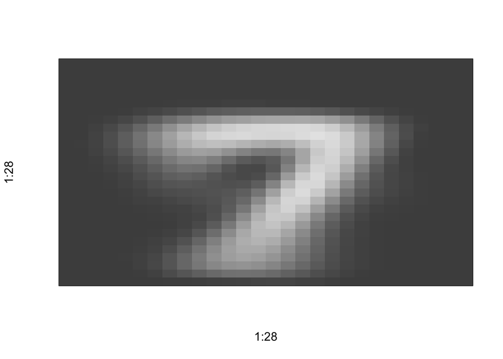

```r
xbar <- colMeans(mnist7)
plot_digit(xbar)
```

Con el conjunto de datos MNIST, aplicaremos el método de Escalamiento Multidimensional (MDS) para facilitar la clasificación y la interpretación visual de los datos. El MDS es una técnica estadística que permite representar datos de alta dimensión en un espacio de menor dimensionalidad, preservando la estructura de distancias entre los puntos en la medida de lo posible. Este enfoque es particularmente útil para explorar la estructura inherente de los datos cuando no hay una metodología de clasificación evidente, o cuando se desea obtener una comprensión intuitiva de las relaciones entre los datos en un espacio bidimensional ( $\mathbb{R}^{2}$) o tridimensional ($\mathbb{R}^{3}$).

En este análisis, aunque ya poseemos conocimientos previos sobre las categorías de los dígitos en el conjunto de datos MNIST, utilizaremos MDS para visualizar y confirmar si los dígitos que comparten características similares en su forma se agrupan en proximidad en un espacio de dimensión reducida. Este procedimiento no solo reafirma las clasificaciones conocidas, sino que también puede revelar patrones subyacentes y agrupaciones que no son inmediatamente evidentes en la representación de alta dimensión original.

**Código**

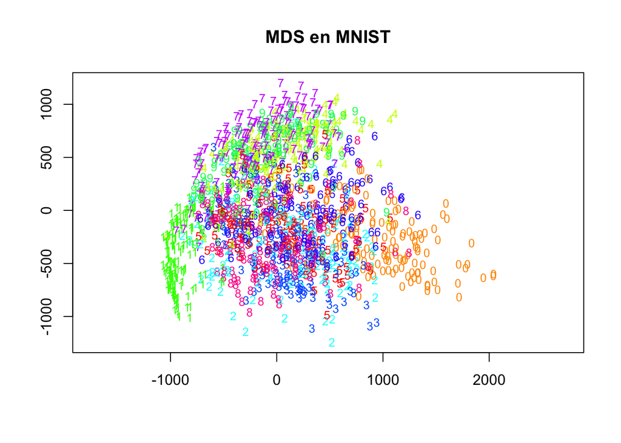

```r
# Tomando solo una muestra de los datos para el ejemplo
mnist_sample <- mnist$train$x[1:1500,,]
mnist_labels_sample <-  mnist$train$y[1:1500]

# Convertir los datos de las imágenes a un formato adecuado para el cálculo de distancias
flat_images <- apply(mnist_sample, 1, as.vector)

# Calcular la matriz de distancias usando la distancia euclidiana
dist_matrix <- dist(t(flat_images))

# Realizar MDS
mds_result <- cmdscale(dist_matrix, k = 2, eig=TRUE, add=TRUE)  # k es el número de dimensiones deseadas, aquí 2 para visualización

# Crear un vector de colores único para cada dígito
unique_labels <- unique(mnist_labels_sample)
colors <- rainbow(length(unique_labels))
label_colors <- colors[match(mnist_labels_sample, unique_labels)]

# Preparar el área de gráficos
plot(mds_result$points, type = 'n', main = "MDS en MNIST", xlab = "", ylab = "", asp = 1)

# Graficar los números de las etiquetas en las coordenadas correspondientes
text(mds_result$points, labels = mnist_labels_sample, col = label_colors, cex=0.8)
```

Los colores se utilizan para diferenciar cada uno de los dígitos, con cada número asignado a un color específico. Esto ayuda a visualizar cómo los diferentes dígitos se agrupan o dispersan en el espacio bidimensional. Por ejemplo, los dígitos que comparten características visuales similares pueden estar más cercanos entre sí, lo que sugiere una proximidad en el espacio de características de alta dimensión original.

La utilidad de esta visualización radica en su capacidad para revelar la estructura relativa y las similitudes entre los dígitos escritos a mano en una forma que puede ser más fácilmente interpretada que en su forma de alta dimensión original. Esto puede ser especialmente valioso para tareas de clasificación y reconocimiento de patrones, ya que proporciona una visión intuitiva de los datos.

## Conclusiones

La aplicación de MDS en el conjunto de datos MNIST ha permitido una visualización clarificadora que destaca la estructura subyacente de los datos. A través de esta representación en dos dimensiones, hemos observado agrupaciones visuales de los dígitos basadas en la similitud de sus características, lo cual facilita enormemente la comprensión y la interpretación de la variabilidad inherente a los datos. La visualización resultante no solo valida las clasificaciones conocidas, sino que también subraya la utilidad del MDS como una herramienta poderosa para la exploración de datos complejos, permitiendo una apreciación intuitiva de las relaciones y diferencias entre los diferentes dígitos.

# Referencias

Wilkinson, Richard. 2023. «6.1.1 Non-Euclidean distance matrices». Online. https://rich-d-wilkinson.github.io/MATH3030/6.1-classical-mds.html#non-euclidean-distance-matrices.